# Assignment 8 - Autocorrelation

## Autocorrelation

#### 1) test for the autocorrelation of the distribution of single women OR single men in Denmark during 2020, and answer the question: "Is the population of single women/men in Denmark spatially correlated? What is the correlation and how significant is the trend?

```r
# read in the data for the Danish Municipalities
mun_sp <- readRDS("data/gadm36_DNK_2_sp.rds")
# transform to an sf object
mun_sf <- st_as_sf(mun_sp)
# make crs to Danish convention
mun <- st_transform(mun_sf, crs = 32632)
# view what the data looks like mapview(mun)


# load attributes from google sheets
DK_civilstatus <- read_sheet("https://docs.google.com/spreadsheets/d/1xcrd07gV3Sm0fuzSIWu2Op36oDBmvvrlHU9uNz49kuU/edit#gid=0")
# write csv for later use write_csv(DK_civilstatus,
# 'data/DKstatdata_civilstatus.csv') DK_civilstatus <-
# read.csv('data/DKstatdata_civilstatus.csv', options = 'ENCODING=WINDOWS-1252')
DK_civilstatus <- DK_civilstatus[complete.cases(DK_civilstatus), ]

# data wrangling checking if we have equal number of municipalities in the two
# data sets
length(mun$NAME_2)  #99
```

```
[1] 99
```

```r
length(unique(DK_civilstatus$Region))  #104
```

```
[1] 104
```

```r
# as we have differing lengths I made a for loop to check which regions differ
for (i in sort(unique(DK_civilstatus$Region))) {
    if (i %in% mun$NAME_2) {
        # do nothing
    } else {
        print(paste(i, "is not in the data!"))
    }
}
```

```
[1] "Aarhus is not in the data!"
[1] "Høje-Taastrup is not in the data!"
[1] "Region Hovedstaden is not in the data!"
[1] "Region Midtjylland is not in the data!"
[1] "Region Nordjylland is not in the data!"
[1] "Region Sjælland is not in the data!"
[1] "Region Syddanmark is not in the data!"
[1] "Vesthimmerlands is not in the data!"
```

```r
# checking if the missing municipalities are missing because of difference in
# spelling
sort(mun$NAME_2)
```

```
 [1] "Aabenraa"          "Aalborg"           "Ærø"
 [4] "Albertslund"       "Allerød"           "Århus"
 [7] "Assens"            "Ballerup"          "Billund"
[10] "Bornholm"          "Brøndby"           "Brønderslev"
[13] "Christiansø"       "Dragør"            "Egedal"
[16] "Esbjerg"           "Faaborg-Midtfyn"   "Fanø"
[19] "Favrskov"          "Faxe"              "Fredensborg"
[22] "Fredericia"        "Frederiksberg"     "Frederikshavn"
[25] "Frederikssund"     "Furesø"            "Gentofte"
[28] "Gladsaxe"          "Glostrup"          "Greve"
[31] "Gribskov"          "Guldborgsund"      "Haderslev"
[34] "Halsnæs"           "Hedensted"         "Helsingør"
[37] "Herlev"            "Herning"           "Hillerød"
[40] "Hjørring"          "Høje Taastrup"     "Holbæk"
[43] "Holstebro"         "Horsens"           "Hørsholm"
[46] "Hvidovre"          "Ikast-Brande"      "Ishøj"
[49] "Jammerbugt"        "Kalundborg"        "Kerteminde"
[52] "København"         "Køge"              "Kolding"
[55] "Læsø"              "Langeland"         "Lejre"
[58] "Lemvig"            "Lolland"           "Lyngby-Taarbæk"
[61] "Mariagerfjord"     "Middelfart"        "Morsø"
[64] "Næstved"           "Norddjurs"         "Nordfyns"
[67] "Nyborg"            "Odder"             "Odense"
[70] "Odsherred"         "Randers"           "Rebild"
[73] "Ringkøbing-Skjern" "Ringsted"          "Rødovre"
 [ reached getOption("max.print") -- omitted 24 entries ]
```

```r
sort(unique(DK_civilstatus$Region))
```

```
 [1] "Aabenraa"           "Aalborg"            "Aarhus"
 [4] "Ærø"                "Albertslund"        "Allerød"
 [7] "Assens"             "Ballerup"           "Billund"
[10] "Bornholm"           "Brøndby"            "Brønderslev"
[13] "Christiansø"        "Dragør"             "Egedal"
[16] "Esbjerg"            "Faaborg-Midtfyn"    "Fanø"
[19] "Favrskov"           "Faxe"               "Fredensborg"
[22] "Fredericia"         "Frederiksberg"      "Frederikshavn"
[25] "Frederikssund"      "Furesø"             "Gentofte"
[28] "Gladsaxe"           "Glostrup"           "Greve"
[31] "Gribskov"           "Guldborgsund"       "Haderslev"
[34] "Halsnæs"            "Hedensted"          "Helsingør"
[37] "Herlev"             "Herning"            "Hillerød"
[40] "Hjørring"           "Høje-Taastrup"      "Holbæk"
[43] "Holstebro"          "Horsens"            "Hørsholm"
[46] "Hvidovre"           "Ikast-Brande"       "Ishøj"
[49] "Jammerbugt"         "Kalundborg"         "Kerteminde"
[52] "København"          "Køge"               "Kolding"
[55] "Læsø"               "Langeland"          "Lejre"
[58] "Lemvig"             "Lolland"            "Lyngby-Taarbæk"
[61] "Mariagerfjord"      "Middelfart"         "Morsø"
[64] "Næstved"            "Norddjurs"          "Nordfyns"
[67] "Nyborg"             "Odder"              "Odense"
[70] "Odsherred"          "Randers"            "Rebild"
[73] "Region Hovedstaden" "Region Midtjylland" "Region Nordjylland"
 [ reached getOption("max.print") -- omitted 29 entries ]
```

```r
# changing the naming in the mun data to match the singles data
which(grepl("Å", mun$NAME_2))  # 31
```

```
[1] 31
```

```r
mun$NAME_2[31] <- "Aarhus"

which(grepl("Vest", mun$NAME_2))  # 60
```

```
[1] 60
```

```r
mun$NAME_2[60] <- "Vesthimmerlands"

which(grepl("Høje", mun$NAME_2))  # 21
```

```
[1] 21
```

```r
mun$NAME_2[21] <- "Høje-Taastrup"

# the last missing data are due to the singles data also being shown per region
# and this we are not interested in
DK_civilstatus <- DK_civilstatus[-grep("Region", DK_civilstatus$Region), ]

# rechecking length of data sets
length(mun$NAME_2)  #99
```

```
[1] 99
```

```r
length(unique(DK_civilstatus$Region))  #99
```

```
[1] 99
```

Now that the data has been cleaned, we can calculate the total numbers of men and women in each municipality and calculate the percentages for single men and women.

```r
# Save number of men and women in each year per region
DK_population <- DK_civilstatus %>% group_by(Region) %>% summarize(sum2015 = sum(Y2015K1),
    sum2016 = sum(Y2016K1), sum2017 = sum(Y2017K1), sum2018 = sum(Y2018K1), sum2019 = sum(Y2019K1),
    sum2020 = sum(Y2020K1)) %>% janitor::adorn_totals(where = "row")

# Check Status categories to know which to exclude from 'single' category
unique(DK_civilstatus$Status)
```

```
[1] "Ugift"          "Gift/separeret" "Enke/enkemand"  "Fraskilt"
```

```r
# Merge the summary with the singles dataset and spatial polygons
singles_per_region <- mun %>% dplyr::select(NAME_2) %>% merge(DK_population, by.x = "NAME_2",
    by.y = "Region") %>% merge(DK_civilstatus, by.x = "NAME_2", by.y = "Region") %>%
    group_by(NAME_2, Sex) %>% filter(Status == "Ugift") %>% mutate(pct_singles_2015 = Y2015K1/sum2015 *
    100, pct_singles_2016 = Y2016K1/sum2016 * 100, pct_singles_2017 = Y2017K1/sum2017 *
    100, pct_singles_2018 = Y2018K1/sum2018 * 100, pct_singles_2019 = Y2019K1/sum2019 *
    100, pct_singles_2020 = Y2020K1/sum2020 * 100)
singles_per_region
```

```
Simple feature collection with 198 features and 21 fields
Geometry type: MULTIPOLYGON
Dimension:     XY
Bounding box:  xmin: 441745.6 ymin: 6049775 xmax: 892801.1 ymax: 6402207
Projected CRS: WGS 84 / UTM zone 32N
# A tibble: 198 x 22
# Groups:   NAME_2, Sex [198]
   NAME_2   sum2015 sum2016 sum2017 sum2018 sum2019 sum2020 Status Sex   Y2020K1
 * <chr>      <dbl>   <dbl>   <dbl>   <dbl>   <dbl>   <dbl> <chr>  <chr>   <dbl>
 1 Aabenraa   58904   58869   59003   59089   59035   58761 Ugift  Kvin~   11645
 2 Aabenraa   58904   58869   59003   59089   59035   58761 Ugift  Mænd    13621
 3 Aalborg   207805  210316  211937  213558  215312  217075 Ugift  Mænd    63634
 4 Aalborg   207805  210316  211937  213558  215312  217075 Ugift  Kvin~   54560
 5 Aarhus    326246  330639  335684  340421  345332  349983 Ugift  Mænd   106838
 6 Aarhus    326246  330639  335684  340421  345332  349983 Ugift  Kvin~  101671
 7 Ærø         6276    6290    6177    6178    6058    5964 Ugift  Mænd     1272
 8 Ærø         6276    6290    6177    6178    6058    5964 Ugift  Kvin~     902
 9 Alberts~   27806   27880   27896   27743   27877   27731 Ugift  Mænd     7390
10 Alberts~   27806   27880   27896   27743   27877   27731 Ugift  Kvin~    6405
# ... with 188 more rows, and 12 more variables: Y2019K1 <dbl>, Y2018K1 <dbl>,
#   Y2017K1 <dbl>, Y2016K1 <dbl>, Y2015K1 <dbl>, geometry <MULTIPOLYGON [m]>,
#   pct_singles_2015 <dbl>, pct_singles_2016 <dbl>, pct_singles_2017 <dbl>,
#   pct_singles_2018 <dbl>, pct_singles_2019 <dbl>, pct_singles_2020 <dbl>
```

```r
# Map some aspect of the result to see no municipalities are missing
# singles_per_region %>% group_by(NAME_2) %>% filter(Sex=='Kvinder') %>% #
# Kvinder select(pct_singles_2015) %>% # 2015 mapview()


# Save for later use
write_rds(singles_per_region, "data/singles_per_region.rds")
```

Data looks good. Now, we can look at singles seperated in sex and year.

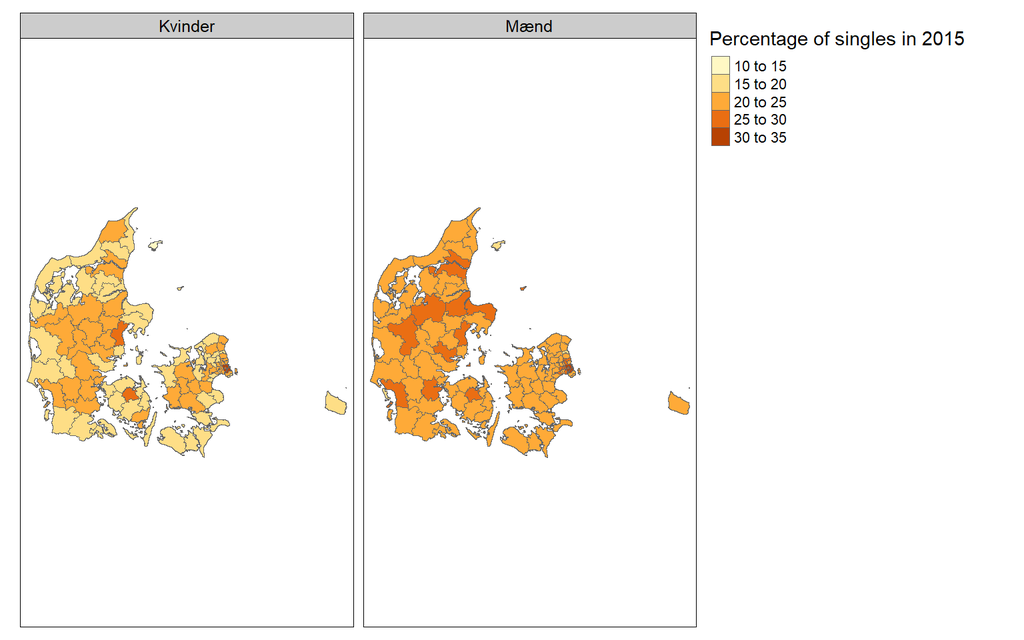

```r
# looking at the yearly trends with tmap map for 2015 with facets by sex
singles_per_region %>% filter(grepl("^M|^K", Sex)) %>% tm_shape() + tm_facets("Sex",
    ncol = 2) + tm_polygons("pct_singles_2015", title = "Percentage of singles in 2015")
```

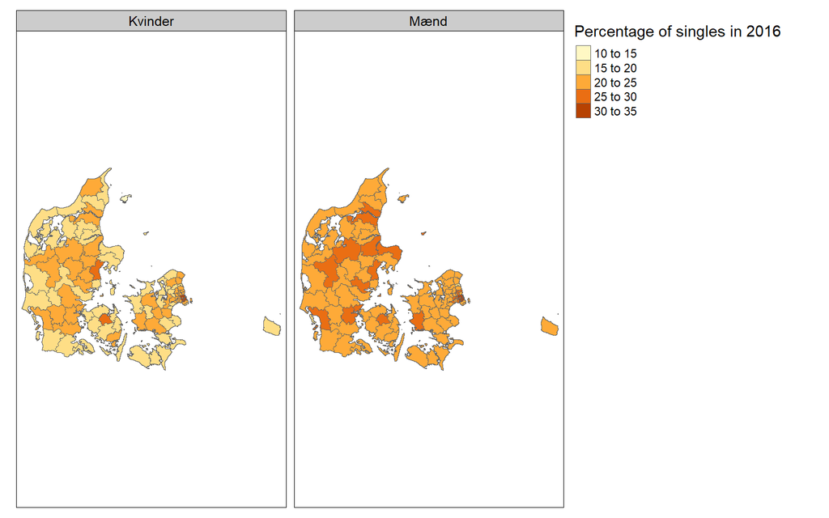

```r
# map for 2016 with facets by sex
singles_per_region %>% filter(grepl("^M|^K", Sex)) %>% tm_shape() + tm_facets("Sex",
    ncol = 2) + tm_polygons("pct_singles_2016", title = "Percentage of singles in 2016")
```

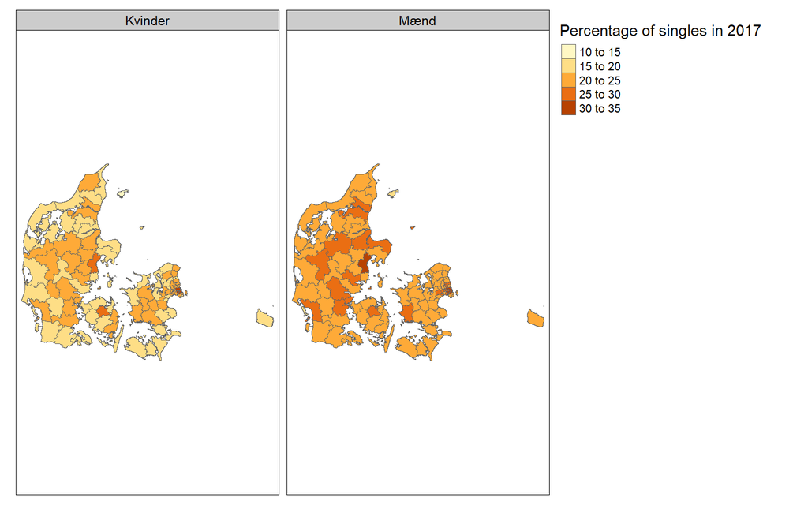

```r
# map for 2017 with facets by sex
singles_per_region %>% filter(grepl("^M|^K", Sex)) %>% tm_shape() + tm_facets("Sex",
    ncol = 2) + tm_polygons("pct_singles_2017", title = "Percentage of singles in 2017")
```

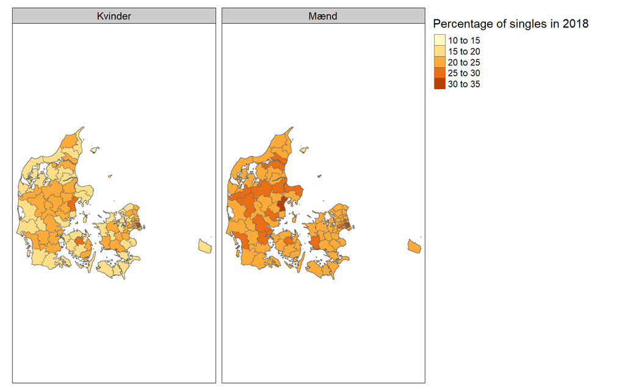

```r
# map for 2018 with facets by sex
singles_per_region %>% filter(grepl("^M|^K", Sex)) %>% tm_shape() + tm_facets("Sex",
    ncol = 2) + tm_polygons("pct_singles_2018", title = "Percentage of singles in 2018")
```

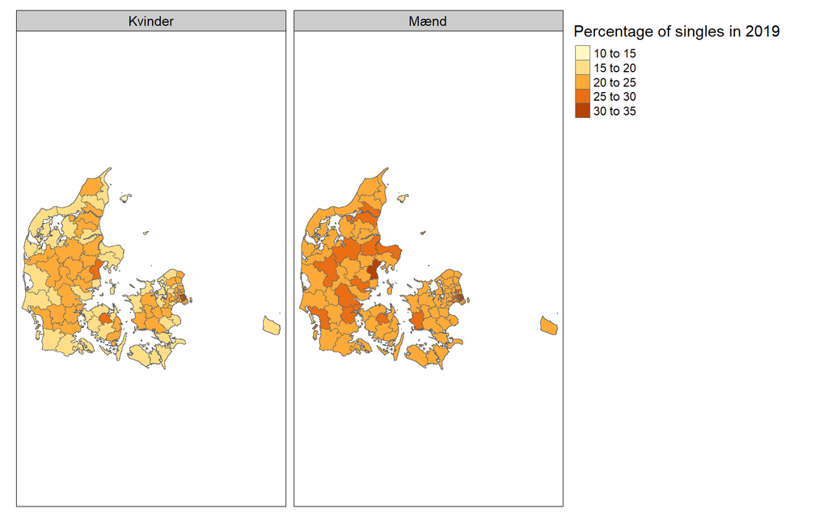

```r
# map for 2019 with facets by sex
singles_per_region %>% filter(grepl("^M|^K", Sex)) %>% tm_shape() + tm_facets("Sex",
    ncol = 2) + tm_polygons("pct_singles_2019", title = "Percentage of singles in 2019")
```

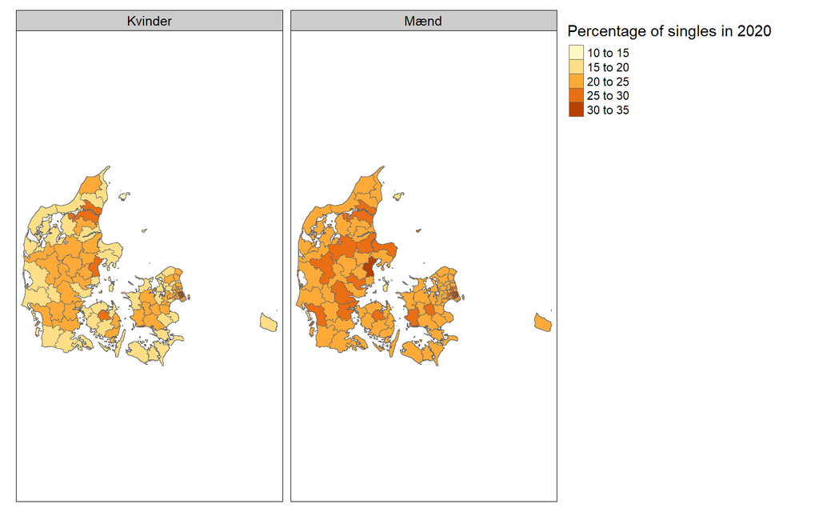

```r
# map for 2020 with facets by sex
singles_per_region %>% filter(grepl("^M|^K", Sex)) %>% tm_shape() + tm_facets("Sex",
    ncol = 2) + tm_polygons("pct_singles_2020", title = "Percentage of singles in 2020")
```

The trends are not drastically changing each year and I think the most notable is that there seems to be generally more men that are unmarried in Denmark compared to women. However, we should be careful when interpreting anything based on with the distribution of percentage of singles.

Lets look at these trends in a more visually intuitive way by making a cartogram. This will expand areas with many singles and shrink areas with low amount of singles.

For this map, I will just focus on the year 2020 but feel free to change the code to also inspect the other years.

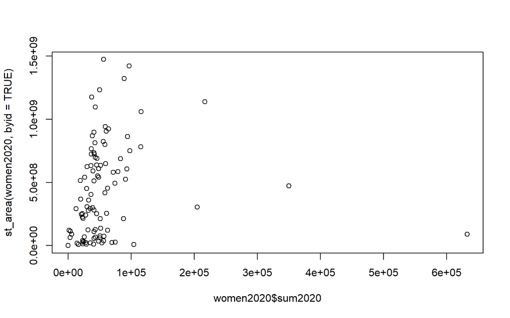

```r
# Let's look at single women in 2020
women2020 <- singles_per_region %>% filter((grepl("^K", Sex)))

# Make a scatterplot of municipality singles versus area and single women and
# municipality area
plot(women2020$sum2020, st_area(women2020, byid = TRUE))
```

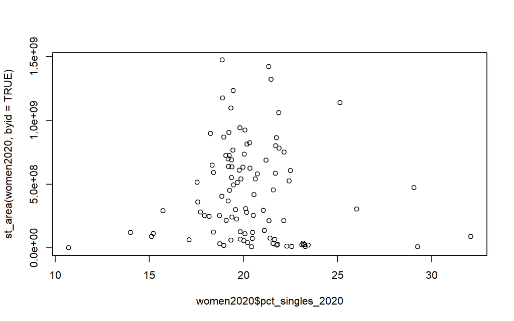

```r
plot(women2020$pct_singles_2020, st_area(women2020, byid = TRUE))
```

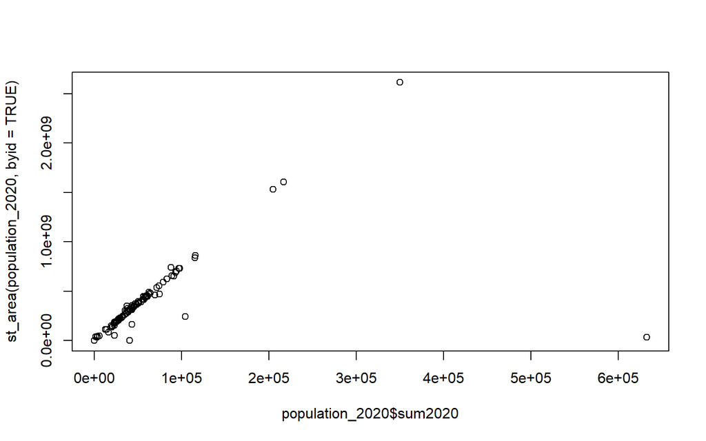

```r
# Make a cartogram, scaling the area to population
population_2020 <- cartogram_cont(women2020, "sum2020")
# Now check the linearity of singles per municipality plot
plot(population_2020$sum2020, st_area(population_2020, byid = TRUE))
```

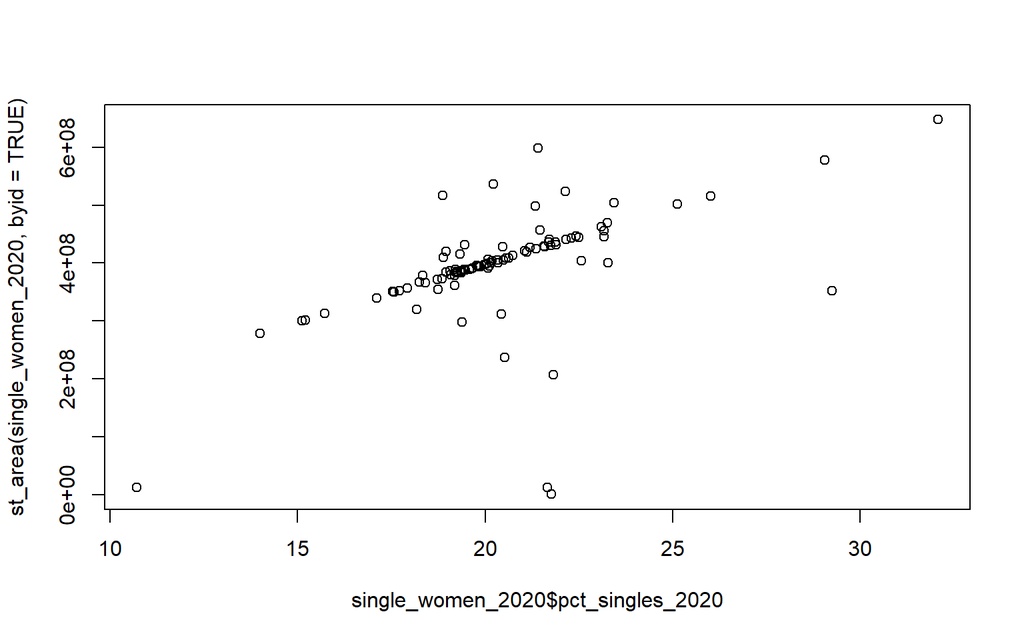

```r
# Make a cartogram, scaling the area to the percentage of single women
single_women_2020 <- cartogram_cont(women2020, "pct_singles_2020")
# Check the linearity of the single women percentage per municipality plot
plot(single_women_2020$pct_singles_2020, st_area(single_women_2020, byid = TRUE))
```

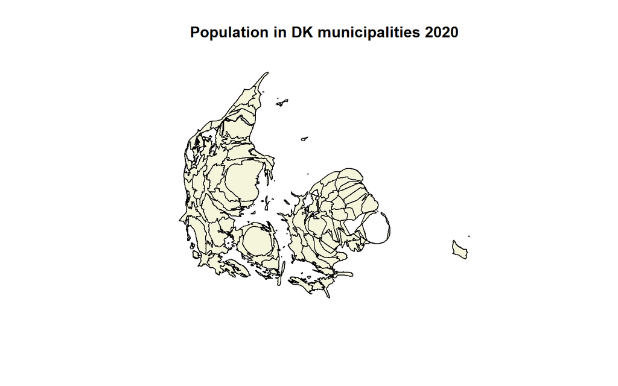

```r
# Make a fairer map of the single women percentage in 2020
plot(population_2020$geometry, col = "beige", main = "Population in DK municipalities 2020")
```

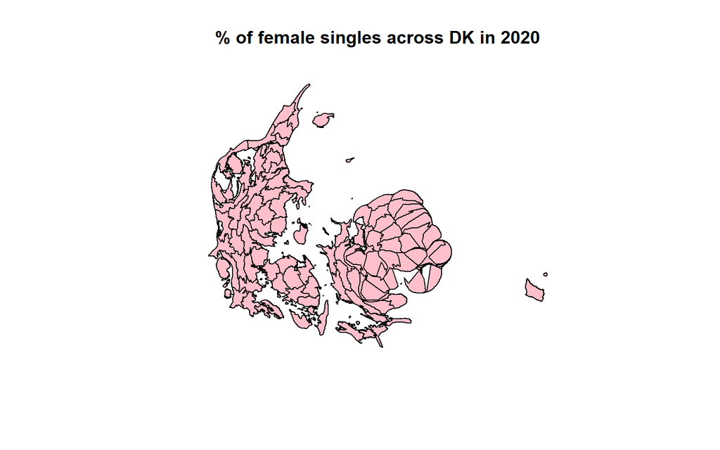

```r
plot(single_women_2020$geometry, col = "pink", main = "% of female singles across DK in 2020")
```

Now for the single men in 2020:

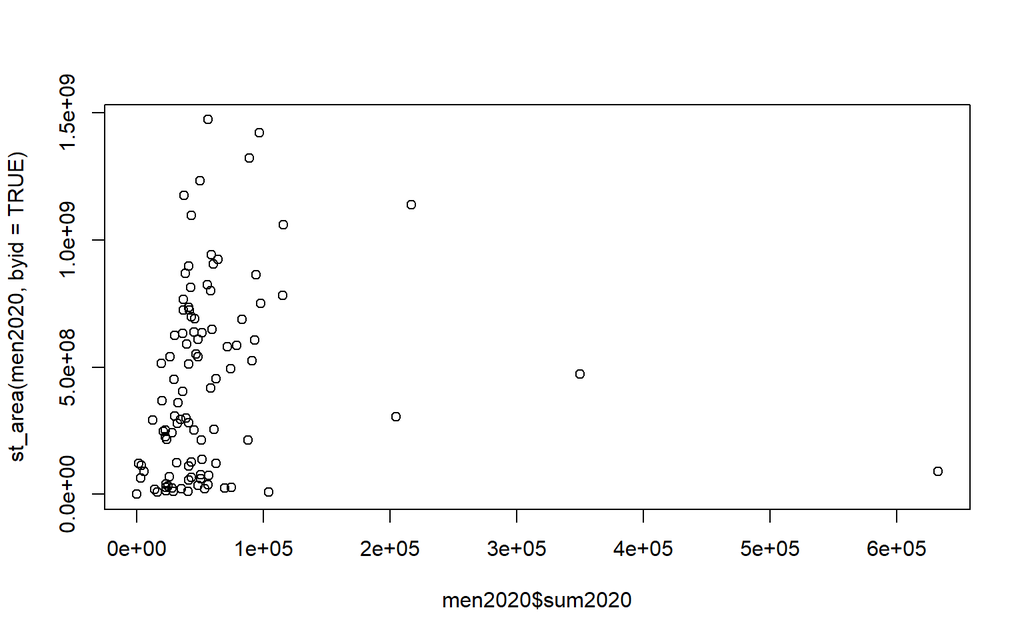

```r
# Let's look at single men in 2020
men2020 <- singles_per_region %>% filter(grepl("^M", Sex))

# Make a scatterplot of municipality singles versus area and single men and
# municipality area
plot(men2020$sum2020, st_area(men2020, byid = TRUE))
```

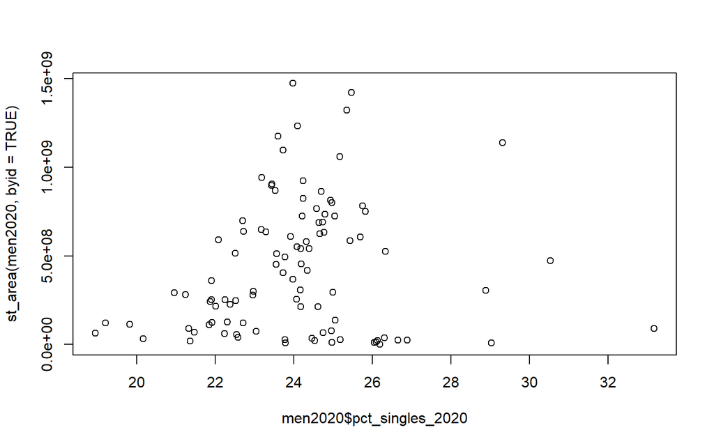

```r
plot(men2020$pct_singles_2020, st_area(men2020, byid = TRUE))
```

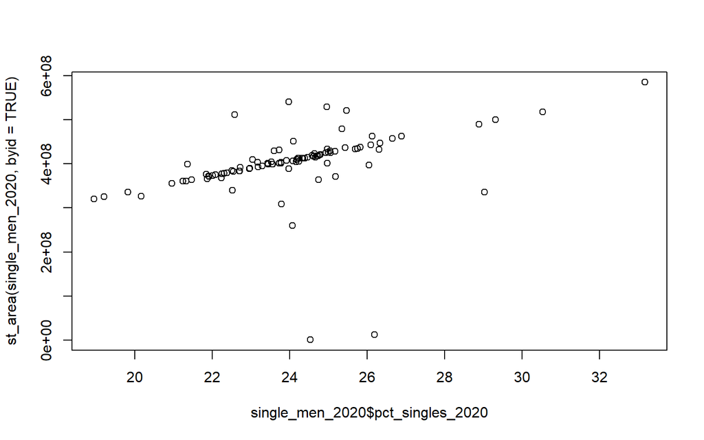

```r
# Make a cartogram, scaling the area to all singles population_2020 <-
# cartogram_cont(men2020, 'sum2020') # same as for women

# Now check the linearity of population per municipality plot
# plot(population_2020$sum2020, st_area(population_2020, byid = TRUE))

# Make a cartogram, scaling the area to the percentage of single men
single_men_2020 <- cartogram_cont(men2020, "pct_singles_2020")

# Check the linearity of the single men percentage per municipality plot
plot(single_men_2020$pct_singles_2020, st_area(single_men_2020, byid = TRUE))
```

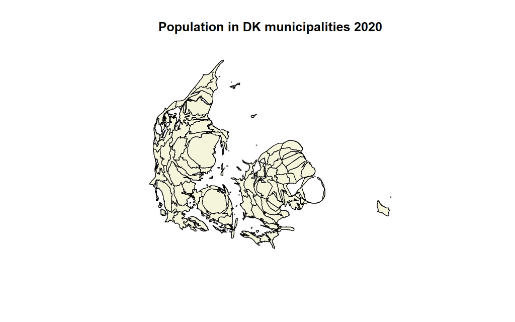

```r
# Make a fairer map of the single men percentage in 2020
plot(population_2020$geometry, col = "beige", main = "Population in DK municipalities 2020")
```

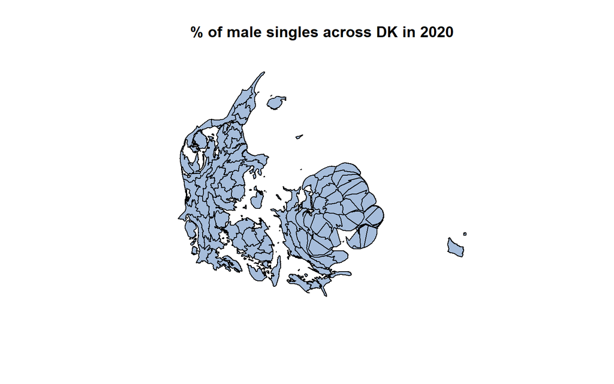

```r
plot(single_men_2020$geometry, col = "#a6bddb", main = "% of male singles across DK in 2020")
```

**Spatial autocorrelation test:**

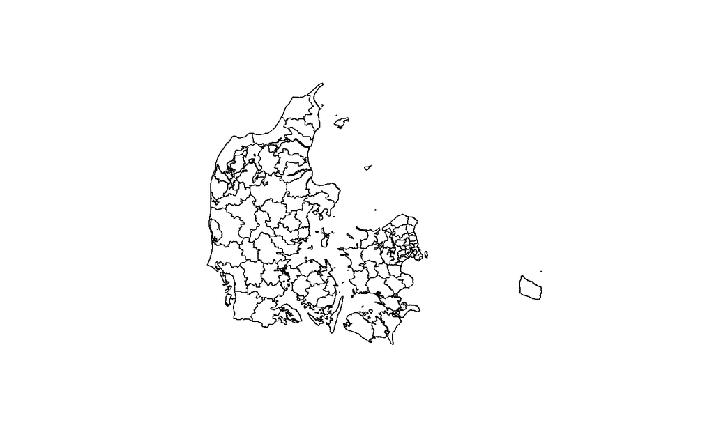

```r
# plot geometry
plot(singles_per_region$geometry)
```

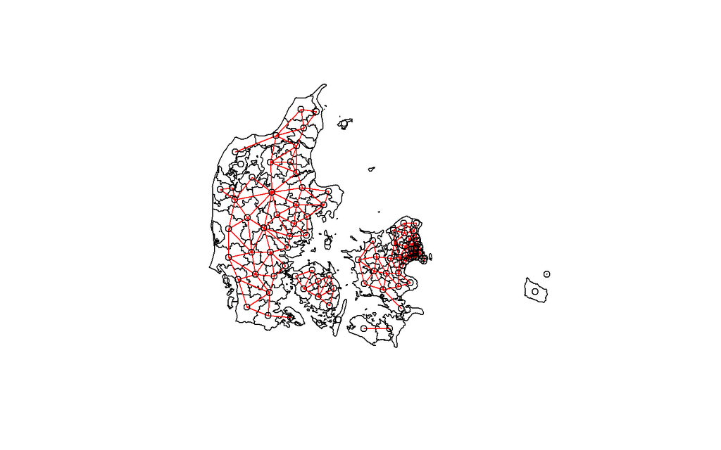

```r
# simplify the boundaries to speed up the processing
mun_sm <- st_cast(st_simplify(mun, dTolerance = 250), to = "MULTIPOLYGON")
# plot simplified geometry
plot(mun_sm$geometry)

# Make neighbor list following queen adjacency
nb <- poly2nb(mun_sm$geometry)
# Get center points of each municipality
mun_centers <- st_coordinates(st_centroid(mun_sm$geometry))
# Show the connections
plot(mun_sm$geometry)
plot(nb, mun_centers, col = "red", add = TRUE)
```

**Calculating Moran’s I for single women across municipalities in DK:**

```r
# Let's look at women in 2020
women2020 <- singles_per_region %>% filter(grepl("^K", Sex))

length(women2020$NAME_2)
```

```
[1] 99
```

```r
length(nb)
```

```
[1] 99
```

```r
# Run a Moran I test on total number of women singles in percentage in 2020
moran.test(women2020$pct_singles_2020, nb2listw(nb, style = "W", zero.policy = TRUE),
    zero.policy = TRUE)
```

```
    Moran I test under randomisation

data:  women2020$pct_singles_2020
weights: nb2listw(nb, style = "W", zero.policy = TRUE)  n reduced by no-neighbour observations


Moran I statistic standard deviate = 0.61014, p-value = 0.2709
alternative hypothesis: greater
sample estimates:
Moran I statistic       Expectation          Variance
      0.035762534      -0.011111111       0.005901925
```

```r
# Morans I = 0.04, p = 0.27

# Do a Monte Carlo simulation to get a better p-value
moran.mc(women2020$pct_singles_2020, nb2listw(nb, zero.policy = TRUE), zero.policy = TRUE,
    nsim = 999)
```

```
    Monte-Carlo simulation of Moran I

data:  women2020$pct_singles_2020
weights: nb2listw(nb, zero.policy = TRUE)
number of simulations + 1: 1000

statistic = 0.035763, observed rank = 747, p-value = 0.253
alternative hypothesis: greater
```

```r
# Morans I = 0.04, p = 0.24
```

The z-value of Moran’s I is very low (z = 0.04) and not significant (p>0.05) both under randomisation and when performing Monte Carlo simulation. This suggests that there the single women are randomly dispersed across municipalities in DK. The positivity of the z-score could indicate slight clustering but still this is not significant.

**Calculating Moran’s I for single men across municipalities in DK:**

```r
# Let's look at women in 2020
men2020 <- singles_per_region %>% filter(grepl("^M", Sex))

# checking that the men2020 have same length as nb
length(men2020$NAME_2)  #99
```

```
[1] 99
```

```r
length(nb)  #99
```

```
[1] 99
```

```r
# Run a Moran I test on total number of women singles in percentage in 2020
moran.test(men2020$pct_singles_2020, nb2listw(nb, style = "W", zero.policy = TRUE),
    zero.policy = TRUE)
```

```
    Moran I test under randomisation

data:  men2020$pct_singles_2020
weights: nb2listw(nb, style = "W", zero.policy = TRUE)  n reduced by no-neighbour observations


Moran I statistic standard deviate = -0.39109, p-value = 0.6521
alternative hypothesis: greater
sample estimates:
Moran I statistic       Expectation          Variance
     -0.041477191      -0.011111111       0.006028844
```

```r
# Moran's I = -0.04, p = 0.65

# Do a Monte Carlo simulation to get a better p-value
moran.mc(men2020$pct_singles_2020, nb2listw(nb, zero.policy = TRUE), zero.policy = TRUE,
    nsim = 999)
```

```
    Monte-Carlo simulation of Moran I

data:  men2020$pct_singles_2020
weights: nb2listw(nb, zero.policy = TRUE)
number of simulations + 1: 1000

statistic = -0.041477, observed rank = 332, p-value = 0.668
alternative hypothesis: greater
```

```r
# Moran's I = -0.04, p = 0.69
```

Again, the z-value of Moran’s I for autocorrelation between distribution of single men across municipalities is very low (z = - 0.04) and not significant (p>0.05) both under randomisation and when performing Monte Carlo simulation. As before, this suggests that there the single men are randomly dispersed. The negativity of the z-score could indicate slight non-random dispersal but still this is not significant.

**Trying to run the same analysis but with d and k nearest neighbor**

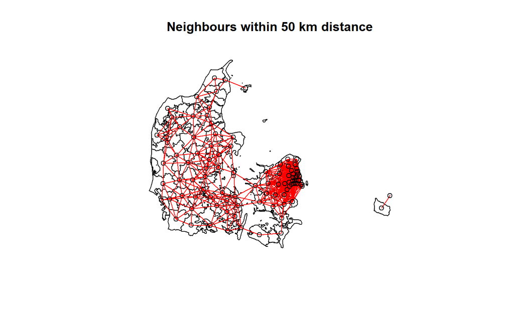

```r
# Get center points of each municipality
mun_centers <- st_centroid(mun_sm$geometry, of_largest_polygon = TRUE)

# Make neighbor list from neighbours at 50km distance
nb_50 <- dnearneigh(mun_centers, 0, 50000)
plot(mun_sm$geometry)
plot(nb_50, mun_centers, col = "red", add = TRUE)
title(main = "Neighbours within 50 km distance")
```

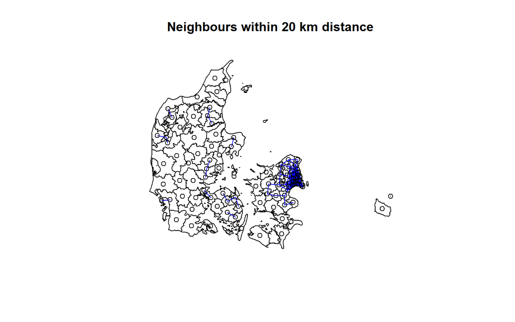

```r
# Make neighbor list from neighbours at 20km distance
nb_20 <- dnearneigh(mun_centers, 0, 20000)
plot(mun_sm$geometry)
plot(nb_20, mun_centers, col = "blue", add = TRUE)
title(main = "Neighbours within 20 km distance")
```

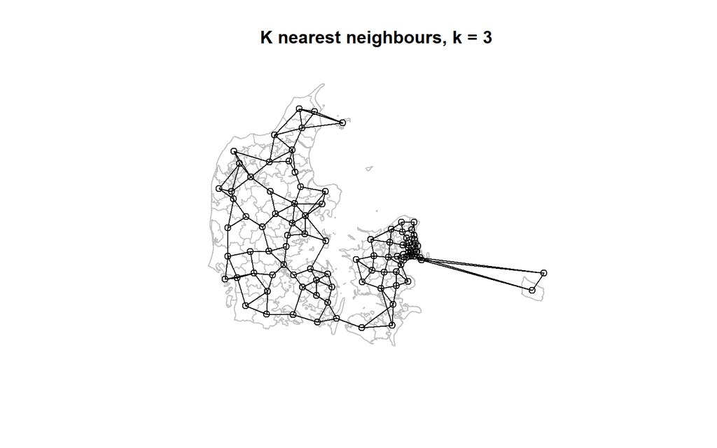

```r
# Make neighbor list from 3 nearest neighbours
coords <- coordinates(as(women2020, "Spatial"))
col.knn <- knearneigh(coords, k = 3)
plot(st_geometry(women2020), border = "grey")
plot(knn2nb(col.knn), coords, add = TRUE)
title(main = "K nearest neighbours, k = 3")
```

## Rerun Moran’s I on single women in DK

Now let’s rerun Moran’s I with different neighbour conceptions for single women in DK - d nearest neighbor: d = 50km - d nearest neighbor: d = 20km - k nearest neighbor: k = 3 neighbors

```r
# Run a Moran I test with Monte Carlo simultion on total number of women singles
# in percentage in 2020 with nearest neighbour distance of 50 km
moran.mc(women2020$pct_singles_2020, nb2listw(nb_50, zero.policy = TRUE), zero.policy = TRUE,
    nsim = 999)
```

```
    Monte-Carlo simulation of Moran I

data:  women2020$pct_singles_2020
weights: nb2listw(nb_50, zero.policy = TRUE)
number of simulations + 1: 1000

statistic = -0.15904, observed rank = 5, p-value = 0.995
alternative hypothesis: greater
```

```r
# Moran's I = -0.16, p = 1.0

# Run a Moran I test with Monte Carlo simultion on total number of women singles
# in percentage in 2020 with nearest neighbour distance of 20 km
moran.mc(women2020$pct_singles_2020, nb2listw(nb_20, zero.policy = TRUE), zero.policy = TRUE,
    nsim = 999)
```

```
    Monte-Carlo simulation of Moran I

data:  women2020$pct_singles_2020
weights: nb2listw(nb_20, zero.policy = TRUE)
number of simulations + 1: 1000

statistic = 0.0082762, observed rank = 599, p-value = 0.401
alternative hypothesis: greater
```

```r
# Moran's I = 0.01, p = 0.40

# Run a Moran I test with Monte Carlo simultion on total number of women singles
# in percentage in 2020 based on 3 neighbours
moran.mc(women2020$pct_singles_2020, nb2listw(knn2nb(col.knn), zero.policy = TRUE),
    zero.policy = TRUE, nsim = 999)
```

```
    Monte-Carlo simulation of Moran I

data:  women2020$pct_singles_2020
weights: nb2listw(knn2nb(col.knn), zero.policy = TRUE)
number of simulations + 1: 1000

statistic = 0.27222, observed rank = 1000, p-value = 0.001
alternative hypothesis: greater
```

```r
# Moran's I = 0.27, p = 0.001
```

Without having a clear hypothesis (which I don’t have) it is difficult to make any inferences based on the results. However, consider this exploratory testing. When looking at the Moran’s I test results it is apparent that both of the d nearest neighbors yielded no significant results and the Moran’s I’s also varied in direction (not a good sign…). However, if we instead look at only the 3 nearest neighbors, there seems to be evidence of clustering (z = 0.27, p < 0.05) between distribution of single women.

## Rerun Moran’s I on single men in DK

Now let’s rerun Moran’s I with different neighbour conceptions for single men in DK - d nearest neighbor: d = 50km - d nearest neighbor: d = 20km - k nearest neighbor: k = 3 neighbors

```r
# Run a Moran I test with Monte Carlo simultion on total number of men singles in
# percentage in 2020 with nearest neighbour distance of 50 km
moran.mc(men2020$pct_singles_2020, nb2listw(nb_50, zero.policy = TRUE), zero.policy = TRUE,
    nsim = 999)
```

```
    Monte-Carlo simulation of Moran I

data:  men2020$pct_singles_2020
weights: nb2listw(nb_50, zero.policy = TRUE)
number of simulations + 1: 1000

statistic = -0.14292, observed rank = 5, p-value = 0.995
alternative hypothesis: greater
```

```r
# Moran's I = -0.14, p = 1.0

# Run a Moran I test with Monte Carlo simultion on total number of men singles in
# percentage in 2020 with nearest neighbour distance of 20 km
moran.mc(men2020$pct_singles_2020, nb2listw(nb_20, zero.policy = TRUE), zero.policy = TRUE,
    nsim = 999)
```

```
    Monte-Carlo simulation of Moran I

data:  men2020$pct_singles_2020
weights: nb2listw(nb_20, zero.policy = TRUE)
number of simulations + 1: 1000

statistic = 0.02177, observed rank = 679, p-value = 0.321
alternative hypothesis: greater
```

```r
# Moran's I = 0.02, p = 0.31

# Run a Moran I test with Monte Carlo simultion on total number of men singles in
# percentage in 2020 based on 3 neighbours
moran.mc(men2020$pct_singles_2020, nb2listw(knn2nb(col.knn), zero.policy = TRUE),
    zero.policy = TRUE, nsim = 999)
```

```
    Monte-Carlo simulation of Moran I

data:  men2020$pct_singles_2020
weights: nb2listw(knn2nb(col.knn), zero.policy = TRUE)
number of simulations + 1: 1000

statistic = 0.17081, observed rank = 990, p-value = 0.01
alternative hypothesis: greater
```

```r
# Moran's I = 0.17, p = 0.01
```

As for single women, when looking at the Moran’s I test results for single men it is apparent that both of the d nearest neighbors (20 and 50km) yielded no significant results and again the Moran’s I’s varied in direction. And just as with the distribution of single women looking at only the 3 nearest neighbors, there seems to be evidence of clustering (z = 0.17, p < 0.05) between distribution of single men. Compared to single women the z score is smaller indicating clustering to a lesser degree. However, this still seems significant.

## **Conclusion:**

**Is the population of single women/men in Denmark spatially correlated? What is the correlation and how significant is the trend?** When testing for spatial autocorrelation for the distribution of single women and men in Denmark in 2020, Moran’s I is not significant when conceptualizing neighbors through the queen’s adjacency, d nearest neighbors within 50 km and 20 km. However, the Moran’s I is significantly positive (z = 0.27, p<0.05) when examining autocorrelation between the three nearest neighbours of each municipality. This indicates that there is a moderate clustering of single women between municipalities. However, we should also take into consideration that when we change our definition of neighbours the direction of the z-value change and become insignificant. And as this is an exploratory investigation more information is needed before one can conclude anything based on these results.

The same applies for single men in Denmark, though with different z-values. However, the same results were encountered in relation to significant/insignificant results. Only the k-nearest neighbour of three yielded significant results (z = 0.17, p<0.05). Compared to single women the clustering between singles in a municipality and it’s three nearest neighbours seem to be to a lesser extent.